# series-informe-total

### Series populares

El siguiente gráfico muestra la cantidad de usuarios por cantidad de llamadas, para cada serie del catálogo SSPM.

Se trazan líneas auxiliares en la media de cada eje, y se sombrea el área que contiene a las series más consultadas y con mayor cantidad de usuarios.

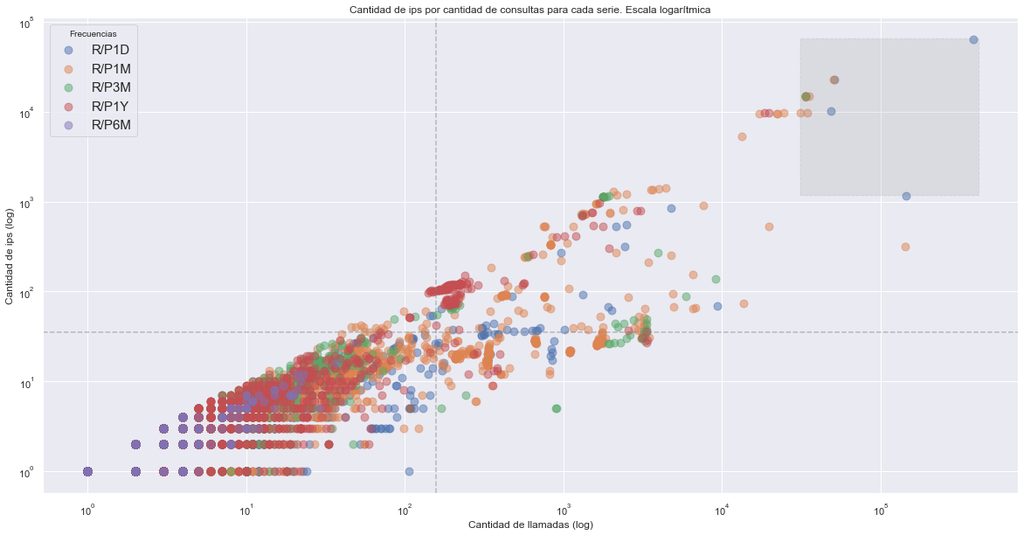

**Las series más populares**

|  | serie_id | serie_descripcion | dataset_tema | dataset_fuente | consultas | usuarios |
| --- | --- | --- | --- | --- | --- | --- |
| 0 | 116.4_TCRZE_2015_D_36_4 | Índice de Tipo de Cambio Real Multilateral | Dinero y Bancos | Banco Central de la República Argentina (BCRA) | 387014 | 63748 |
| 1 | 74.3_ISC_0_M_19 | Saldo comercial. En millones de dólares. | Sector Externo | Instituto Nacional de Estadística y Censos (INDEC) | 50619 | 22572 |
| 2 | 89.2_TS_INTE_PM_0_D_16 | Instrumentos del BCRA. Tasa de Política Monetaria. | Dinero y Bancos | Banco Central de la República Argentina (BCRA) | 51350 | 22570 |
| 3 | 145.3_INGNACUAL_DICI_M_38 | Tasa de variación mensual del Índice de Precios al Consumidor. Nivel General Nacional. Base diciembre 2016. Valores mensuales. | Precios | Instituto Nacional de Estadística y Censos (INDEC) | 35579 | 14817 |
| 4 | 169.1_MALVAL_0_0_6 | Índice Merval del IAMC | Mercados Financieros | Instituto Argentino de Mercado de Capitales (IAMC) | 33678 | 14775 |
| 5 | 45.2_ECTDT_0_T_33 | Tasa de desempleo total. En porcentaje. | Empleo e Ingresos | Instituto Nacional de Estadística y Censos (INDEC) | 33602 | 14761 |
| 6 | 38.3_CEM_1994_M_7 | Ventas al mercado interno de Producción Nacional de cemento en miles de toneladas | Actividad | Instituto Nacional de Estadística y Censos (INDEC) | 33558 | 14760 |
| 7 | 131.1_FET_0_0_12 | FF (Federal Funds) - EE.UU - Tasa | Economía Internacional | Bancos Centrales | 33543 | 14754 |
| 8 | 143.3_ICE_SER_VM_2004_A_34 | EMAE desestacionalizado. Base 2004. Variación % mensual | Actividad | Instituto Nacional de Estadística y Censos (INDEC) | 33546 | 14751 |
| 9 | 172.3_TL_RECA_IA_M_0_0_24 | Total recaudación. Variación interanual | Finanzas Públicas | Cámara Argentina de Fondos Comunes de Inversión | 33534 | 14732 |
| 10 | 154.2_COBAOBA_S_0_0_7 | Asalariados registrados del sector privado según provincia cordoba | Empleo e Ingresos | Ministerio de Trabajo, Empleo y Seguridad Social | 33510 | 14727 |
| 11 | 168.1_T_CAMBIOR_D_0_0_26 | Tipo de Cambio BNA (Vendedor) | Mercados Financieros | BCRA, MAE, Rofex | 48827 | 10105 |
| 12 | 143.3_NO_PR_2004_A_21 | EMAE. Base 2004 | Actividad | Instituto Nacional de Estadística y Censos (INDEC) | 31234 | 9811 |
| 13 | 148.3_INIVELNAL_DICI_M_26 | Índice de Precios al Consumidor. Nivel General Nacional. Base diciembre 2016. Valores mensuales. | Precios | Instituto Nacional de Estadística y Censos (INDEC) | 34545 | 9741 |
| 14 | 94.2_UVAD_D_0_0_10 | UVA diario | Dinero y Bancos | Banco Central de la República Argentina (BCRA) | 145011 | 1165 |

**Tabla 4**

# Cantidad de llamadas

## Perfil de las series

Promedio por día y por semana de las consultas a las series del catálogo SSPM:

|  | promedio |
| --- | --- |
| por día | 18.449,90 |
| por semana | 127.099,33 |

### Perfil de series diarias

A continuación se presenta el promedio de llamadas por hora y por día de la semana para las series diarias.

Se observa que los valores son mayores para las horas de oficina, por lo que se entiende que detrás del consumo de las series hay un factor de trabajo humano ascociado.

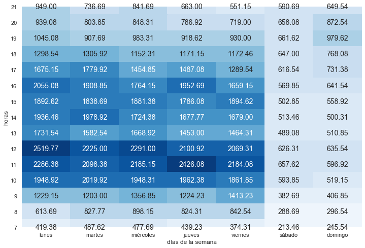

# Cantidad de usuarios

En esta sección se describe el comportamiento de los usuarios que consumen series del catálogo SSPM en la API Series de Tiempo.

## Comportamiento de usuarios segmentados por tipo de consumo

Para entender el comportamiento de los usuarios, se consideran las siguientes variables:

- *persistencia*: proporción de semanas en las que el usuario utilizó el servicio en el período considerado, y
- *actividad*: promedio diario de consultas realizadas en el período considerado.

### Descripción de la variables

**Medidias de las variables**

|  | actividad | persistencia |
| --- | --- | --- |
| mean | 6.63 | 12.87 |
| std | 20.44 | 12.25 |
| min | 1.00 | 7.14 |
| max | 1,896.00 | 100.00 |

**Tabla 5**

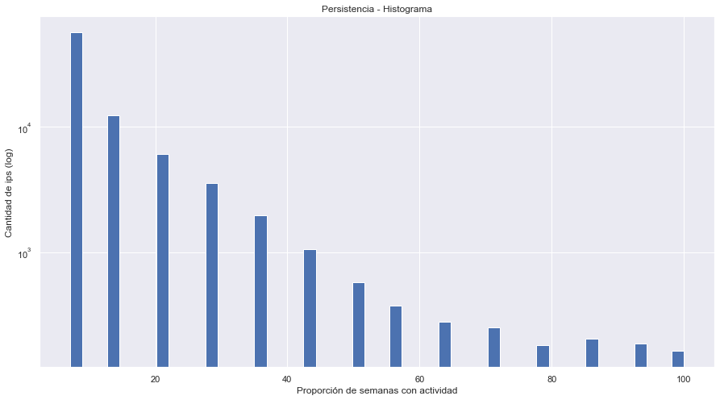

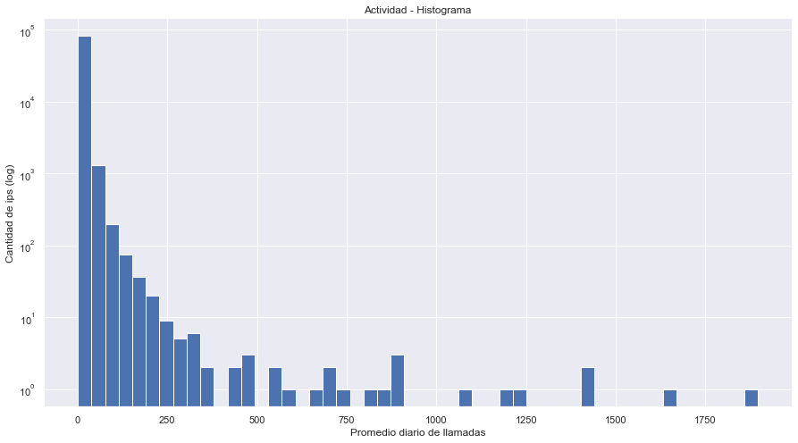